# prueba_sin_datos_de_hoteles_y_cluster_para_vecindario

##### Mejorando el modelo

Podemos intentar usar la Ridge Regularization para disminuir la influencia de características menos importantes. La regularización de ridges es un proceso que reduce los coeficientes de regresión de las características menos importantes.

Creamos una nueva instancia del modelo. El modelo de regularización de Ridge toma un parámetro, alfa, que controla la fuerza de la regularización.

Experimentaremos recorriendo algunos valores diferentes de alfa y veremos cómo esto cambia nuestros resultados.

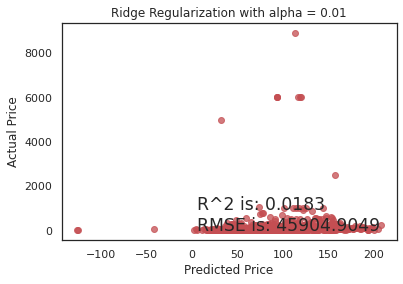

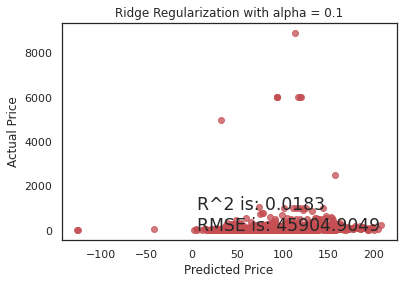

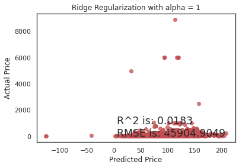

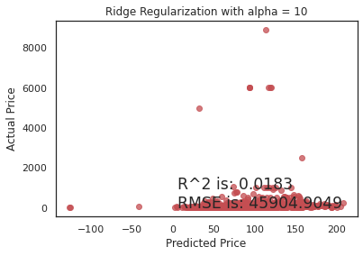

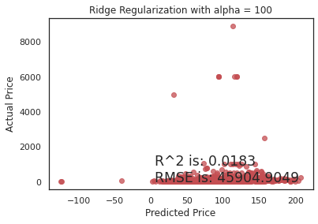

```python
lr = linear_model.LinearRegression()

for i in range (-2, 3):
    alpha = 10**i
    rm = linear_model.Ridge(alpha=alpha)
    ridge_model = rm.fit(X_train, y_train)
    preds_ridge = ridge_model.predict(X_test)

    plt.scatter(preds_ridge, actual_values, alpha=.75, color='r')
    plt.xlabel('Predicted Price')
    plt.ylabel('Actual Price')
    plt.title('Ridge Regularization with alpha = {}'.format(alpha))
    overlay = 'R^2 is: {}\nRMSE is: {}'.format(
                   round(ridge_model.score(X_test, y_test), 4),
                    round(mean_squared_error(y_train, training_preds_hpm_reg),4))
    plt.annotate( s=overlay,xy=(5.5,2.5),size='x-large')
    plt.show()
```

Los dos modelos tienen casi la misma performance y ajustar las alfas no ha mejorado nuestro modelo

#### Modelo 2: Gradient boosted decision trees

El refuerzo es una técnica de conjunto donde se agregan nuevos modelos para corregir los errores cometidos por los modelos existentes. Los modelos se agregan secuencialmente hasta que no se puedan realizar más mejoras. Un ejemplo popular es el algoritmo AdaBoost que pondera los puntos de datos que son difíciles de predecir.

El aumento de gradiente es un enfoque donde se crean nuevos modelos que predicen los residuos o errores de modelos anteriores y luego se suman para hacer la predicción final. Se llama aumento de gradiente porque utiliza un algoritmo de descenso de gradiente para minimizar la pérdida al agregar nuevos modelos.

XGBoost (eXtreme Gradient Boosting) es una implementación de árboles de decisión potenciados por gradiente diseñados para la velocidad y el rendimiento. Es un algoritmo muy popular que recientemente ha dominado el aprendizaje automático aplicado para datos estructurados o tabulares.

Este enfoque admite problemas de modelado predictivo de regresión y clasificación. Para obtener más información, vea aquí para escuchar a Tianqi Chen, el creador de la biblioteca XGBoost.

Es muy probable que este modelo proporcione la mejor precisión posible y una medida de la importancia de la característica en comparación con nuestra regresión hedónica (aparte de los posibles pequeños aumentos de precisión de la sintonización de hiperparámetros) debido al rendimiento superior de XGBoost.

```python
xgb_reg_start = time.time()

xgb_reg = xgb.XGBRegressor()
xgb_reg.fit(X_train, y_train)
training_preds_xgb_reg = xgb_reg.predict(X_train)
val_preds_xgb_reg = xgb_reg.predict(X_test)

xgb_reg_end = time.time()

print(f"Time taken to run: {round((xgb_reg_end - xgb_reg_start)/60,1)} minutes")
print("\nTraining MSE:", round(mean_squared_error(y_train, training_preds_xgb_reg),4))
print("Validation MSE:", round(mean_squared_error(y_test, val_preds_xgb_reg),4))
print("\nTraining r2:", round(r2_score(y_train, training_preds_xgb_reg),4))
print("Validation r2:", round(r2_score(y_test, val_preds_xgb_reg),4))
```

```
[19:25:10] WARNING: /workspace/src/objective/regression_obj.cu:152: reg:linear is now deprecated in favor of reg:squarederror.
Time taken to run: 0.0 minutes

Training MSE: 13299.7689
Validation MSE: 21785.1731

Training r2: 0.7164
Validation r2: 0.682
```

**Esto significa que nuestras características explican aproximadamente el 68% de la varianza en nuestra variable objetivo.**